# Heart Droplet Notebook

Specify the tissue of interest, run the boilerplate code which sets up the functions and environment, load the tissue object.

```
|----|----|----|----|----|----|----|----|----|----|
```

```
[1] "Scaling data matrix"
```

```
|----|----|----|----|----|----|----|----|----|----|
|----|----|----|----|----|----|----|----|----|----|
```

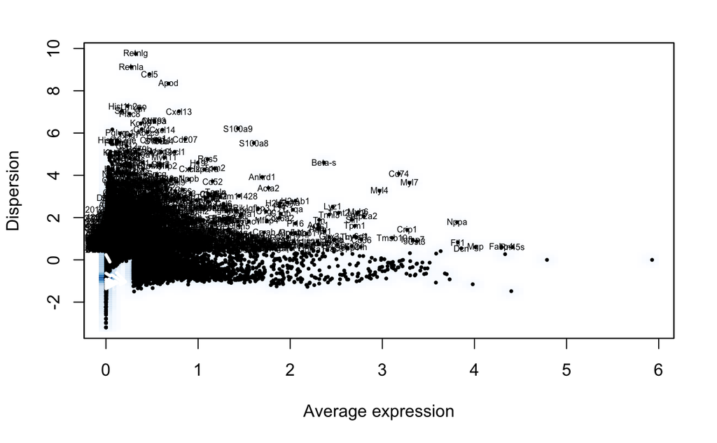

```r
tissue_of_interest = "Heart"
library(here)
source(here("00_data_ingest", "02_tissue_analysis_rmd", "boilerplate.R"))
tiss=load_tissue_droplet(tissue_of_interest)
```

Visualize top genes in principal components

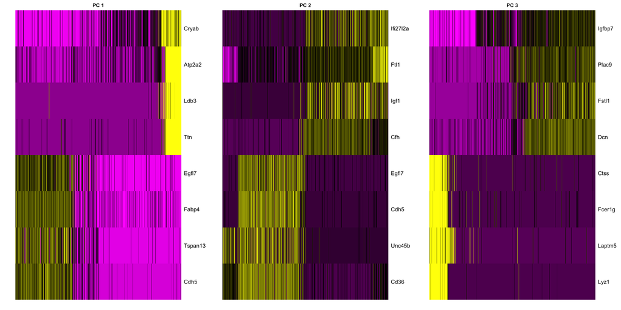

Later on (in FindClusters and TSNE) you will pick a number of principal components to use. This has the effect of keeping the major directions of variation in the data and, ideally, supressing noise. There is no correct answer to the number to use, but a decent rule of thumb is to go until the plot plateaus.

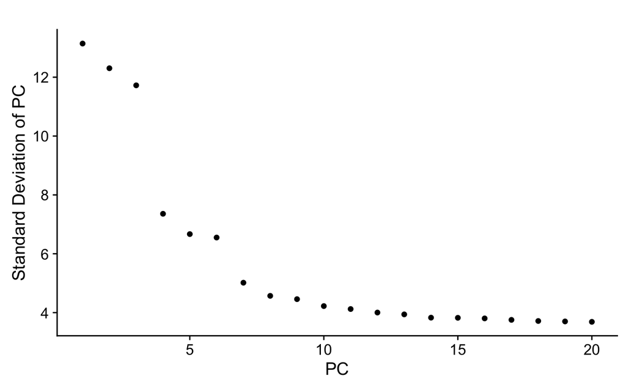

```r
PCElbowPlot(object = tiss)
```

Choose the number of principal components to use.

```r
# Set number of principal components.
n.pcs = 9
```

The clustering is performed based on a nearest neighbors graph. Cells that have similar expression will be joined together. The Louvain algorithm looks for groups of cells with high modularity–more connections within the group than between groups. The resolution parameter determines the scale…higher resolution will give more clusters, lower resolution will give fewer.

For the top-level clustering, aim to under-cluster instead of over-cluster. It will be easy to subset groups and further analyze them below.

```r
# Set resolution
res.used <- 0.5
tiss <- FindClusters(object = tiss, reduction.type = "pca", dims.use = 1:n.pcs,
    resolution = res.used, print.output = 0, save.SNN = TRUE)
```

To visualize

```r
# If cells are too spread out, you can raise the perplexity. If you have few cells, try a lower perplexity (but never less than 10).
tiss <- RunTSNE(object = tiss, dims.use = 1:n.pcs, seed.use = 10, perplexity=30, dim.embed = 2)
```

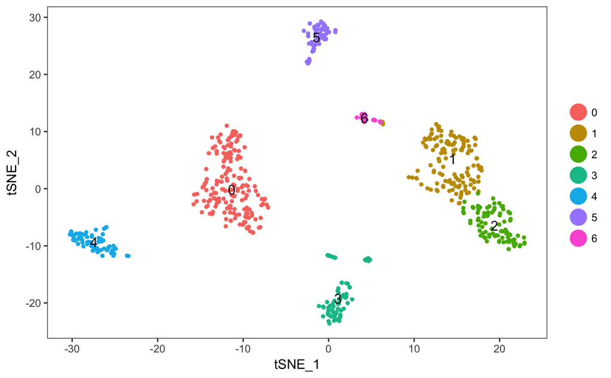

```r
# note that you can set do.label=T to help label individual clusters
TSNEPlot(object = tiss, do.label = T)
```

Check expression of genes of interset.

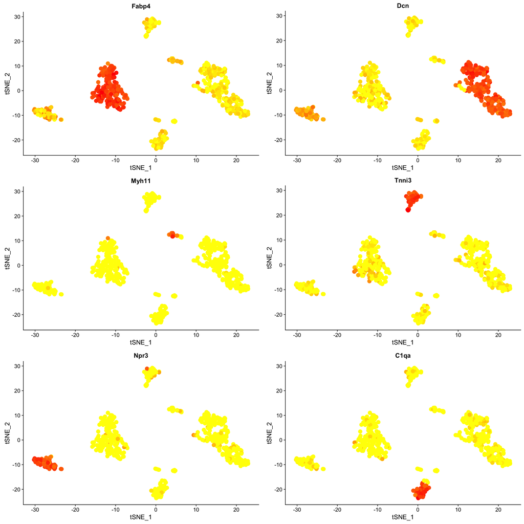

How big are the clusters?

```r
table(tiss@ident)
```

[output not shown]

Which markers identify a specific cluster?

```r
clust.markers <- FindMarkers(object = tiss, ident.1 = 2, ident.2 = 1, only.pos = TRUE, min.pct = 0.25, thresh.use = 0.25)
```

```r
print(x = head(x= clust.markers, n = 10))
```

[output not shown]

You can also compute all markers for all clusters at once. This may take some time.

```r
tiss.markers <- FindAllMarkers(object = tiss, only.pos = TRUE, min.pct = 0.25, thresh.use = 0.25)
```

Display the top markers you computed above.

```r
#tiss.markers %>% group_by(cluster) %>% top_n(5, avg_diff)
```

## Assigning cell type identity to clusters

At a coarse level, we can use canonical markers to match the unbiased clustering to known cell types:

0: Coronary_vascular_EDC 1: Fb 2: Fb 3: Blood_Cells 4: Endocardial_EDC 5: CMs 6: SMC

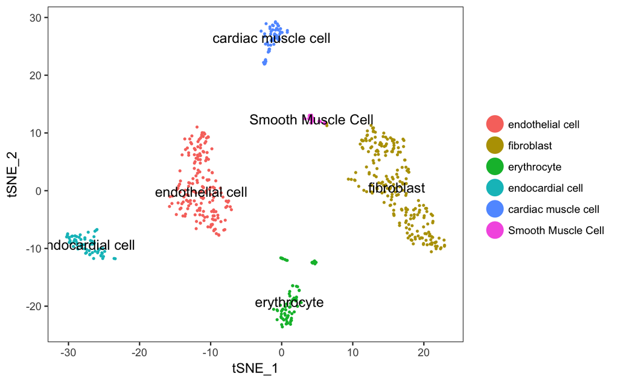

```r
# stash current cluster IDs
tiss <- StashIdent(object = tiss, save.name = "cluster.ids")
# enumerate current cluster IDs and the labels for them
cluster.ids <- c(0, 1, 2, 3, 4, 5,6)
cell_ontology_class <- c("endothelial cell", "fibroblast","fibroblast", "erythrocyte",  "endocardial cell", "cardiac muscle cell", "Smooth Muscle Cell")
cell_ontology_id <- c("CL:0000115", "CL:0000057", "CL:0000057", "CL:0002350", "CL:0000746", "CL:0000232", "CL:0000192")
tiss@meta.data[,'cell_ontology_class'] <- plyr::mapvalues(x = tiss@ident, from = cluster.ids, to = cell_ontology_class)
tiss@meta.data[,'cell_ontology_id'] <- plyr::mapvalues(x = tiss@ident, from = cluster.ids, to = cell_ontology_id)
tiss@meta.data[tiss@cell.names,'cell_ontology_class'] <- as.character(tiss@meta.data$cell_ontology_class)
tiss@meta.data[tiss@cell.names,'cell_ontology_id'] <- as.character(tiss@meta.data$cell_ontology_id)
TSNEPlot(object = tiss, do.label = TRUE, pt.size = 0.5, group.by='cell_ontology_class')
```

## Checking for batch effects

Color by metadata, like plate barcode, to check for batch effects.

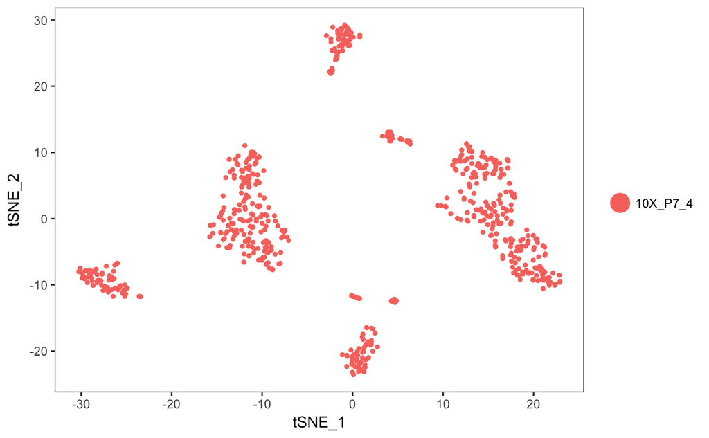

```r
TSNEPlot(object = tiss, do.return = TRUE, group.by = "channel")
```

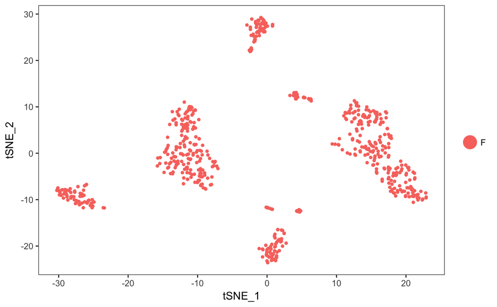

```r
TSNEPlot(object = tiss, do.return = TRUE, group.by = "mouse.sex")
```

Print a table showing the count of cells in each identity category from each plate.

```r
table(as.character(tiss@ident), as.character(tiss@meta.data$channel))
```

```
    10X_P7_4
  0      177
  1      135
  2       87
  3       81
  4       63
  5       60
  6       21
```

# Subset and iterate

We can repeat the above analysis on a subset of cells, defined using cluster IDs or some other metadata. This is a good way to drill down and find substructure.

## First subset

```r
# Subset data based on cluster id
subtiss <- SubsetData(object = tiss, ident.use = c(2), do.center = F, do.scale = F, cells.use = )
# To subset data based on cell_ontology_class or other metadata, you can explicitly pass cell names
#cells.to.use = tiss@cell.names[which(tiss@meta.data$mouse.sex == 'F')]
#subtiss <- SubsetData(object = tiss, cells.use = cells.to.use, do.center = F, do.scale = F)
```

```r
subtiss <- NormalizeData(object = subtiss)
```

```
|----|----|----|----|----|----|----|----|----|----|
```

```r
subtiss <- ScaleData(object = subtiss, vars.to.regress = c("nUMI", "percent.ribo","Rn45s"))
```

```
[1] "Regressing out nUMI"         "Regressing out percent.ribo"
[3] "Regressing out Rn45s"

[1] "Scaling data matrix"
```

Run Principal Component Analysis.

```
|----|----|----|----|----|----|----|----|----|----|
|----|----|----|----|----|----|----|----|----|----|
```

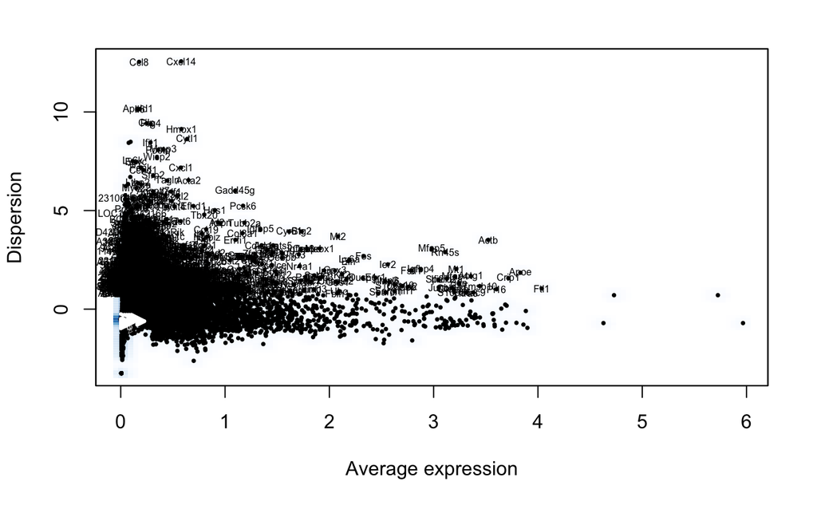

```r
subtiss <- FindVariableGenes(object = subtiss, do.plot = TRUE, x.high.cutoff = Inf, y.cutoff = 0.8)
```

```r
subtiss <- RunPCA(object = subtiss, pcs.compute = 20, weight.by.var = F)
```

```
[1] "PC1"
 [1] "Igfbp6"  "S100a6"  "Gpr133"  "Lrrn4cl" "Fndc1"   "Cd248"   "Adamts5" "Crip1"
 [9] "Efhd1"   "Mustn1"  "Stmn4"   "Pla1a"   "Cadm3"   "Loxl2"   "Flnb"    "Pcsk6"
[17] "Sema3c"  "Gfpt2"   "Anxa3"   "Pcolce2" "Limch1"  "Basp1"   "Ly6c1"   "Cxcr7"
[25] "Ahdc1"   "Carhsp1" "Nov"     "Prelp"   "Ret"     "Nhsl1"
[1] ""
 [1] "Mfap4"         "Apoe"          "Crispld2"      "Igf1"          "Fbln1"
 [6] "Ndrg2"         "Heyl"          "Eln"           "Cxcl12"        "Podn"
[11] "Osr1"          "Mt1"           "Ccl19"         "Nr4a1"         "Stc2"
[16] "Foxs1"         "Tgfb3"         "Aspa"          "Tgfbi"         "Cpe"
[21] "Msx1"          "Slco2b1"       "S1pr3"         "Gt(ROSA)26Sor" "2610524H06Rik"
[26] "Sesn3"         "Trim24"        "Pdgfrl"        "Mfap2"         "Xpnpep1"
[1] ""
[1] ""
[1] "PC2"
```

[output cut: 60 more lines]

```r
subtiss <- ProjectPCA(object = subtiss, do.print = FALSE)
```

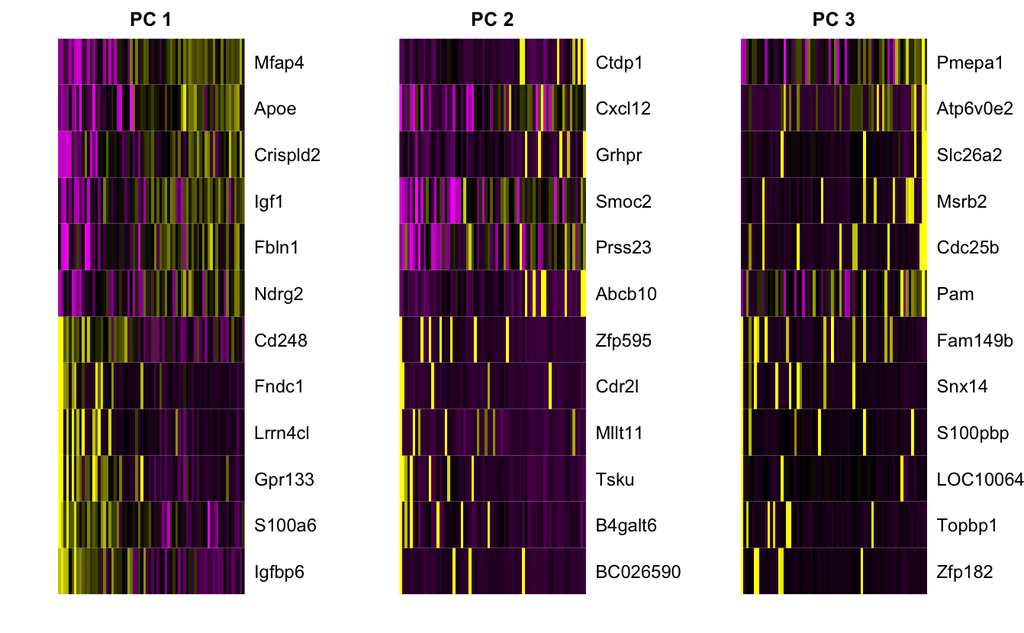

```r
# If this fails for your subset, it may be that cells.use is more cells than you have left! Try reducing it.
PCHeatmap(object = subtiss, pc.use = 1:3, cells.use = 70, do.balanced = TRUE, label.columns = FALSE, num.genes = 12)
```

Later on (in FindClusters and TSNE) you will pick a number of principal components to use. This has the effect of keeping the major directions of variation in the data and, ideally, supressing noise. There is no correct answer to the number to use, but a decent rule of thumb is to go until the plot plateaus.

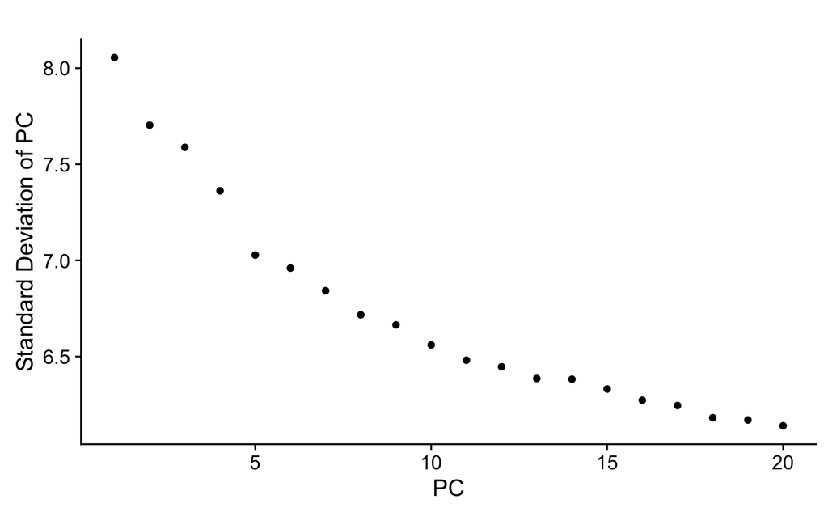

```r
PCElbowPlot(object = subtiss)
```

Choose the number of principal components to use.

```r
# Set number of principal components.
sub.n.pcs = 5
```

The clustering is performed based on a nearest neighbors graph. Cells that have similar expression will be joined together. The Louvain algorithm looks for groups of cells with high modularity–more connections within the group than between groups. The resolution parameter determines the scale…higher resolution will give more clusters, lower resolution will give fewer.

```r
# Set resolution
sub.res.used <- 1
subtiss <- FindClusters(object = subtiss, reduction.type = "pca", dims.use = 1:sub.n.pcs,
    resolution = sub.res.used, ,print.output = 0, save.SNN = TRUE)
```

To visualize

```r
# If cells are too spread out, you can raise the perplexity. If you have few cells, try a lower perplexity (but never less than 10).
subtiss <- RunTSNE(object = subtiss, dims.use = 1:sub.n.pcs, seed.use = 10, perplexity=20)
```

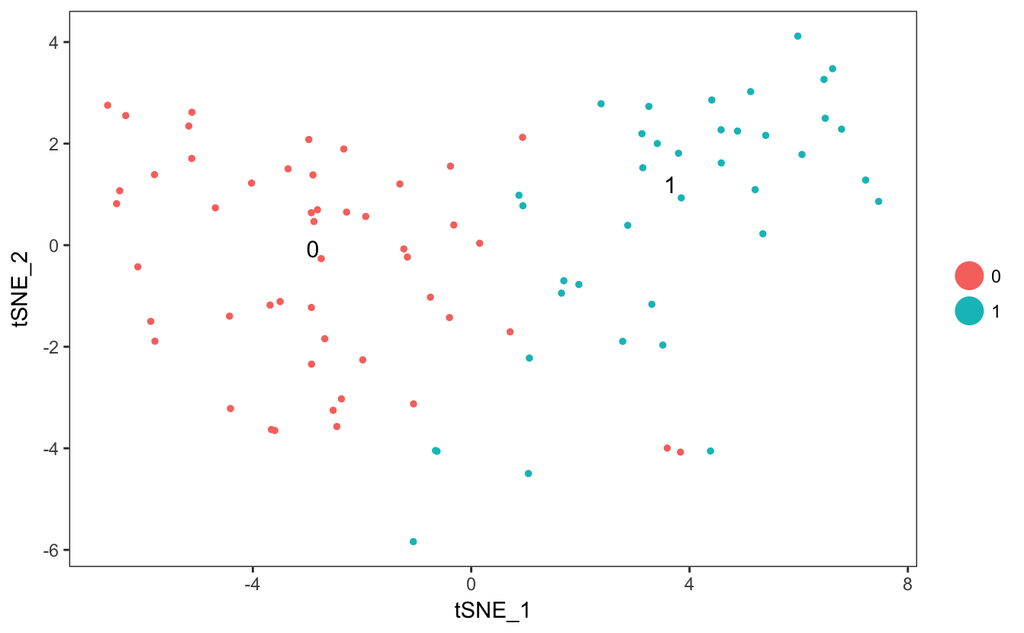

```r
# note that you can set do.label=T to help label individual clusters
TSNEPlot(object = subtiss, do.label = T)
```

```r
subtiss.markers <- FindAllMarkers(object = subtiss, only.pos = TRUE, min.pct = 0.25, thresh.use = 0.25)
```

[output not shown]

[output cut: 130 more lines]

[output not shown]

```r
subtiss.markers %>% group_by(cluster) %>% top_n(6, avg_diff)
```

| p_val | avg_diff | pct.1 | pct.2 | cluster | gene |
| --- | --- | --- | --- | --- | --- |
| 3.892720e-07 | 0.7758858 | 0.898 | 0.711 | 0 | Ndrg2 |
| 6.566498e-06 | 0.7282920 | 1.000 | 0.711 | 0 | Mfap4 |
| 3.123360e-05 | 1.1346763 | 0.755 | 0.500 | 0 | Btg2 |
| 1.841026e-04 | 0.7913725 | 0.898 | 0.553 | 0 | Nr4a1 |
| 4.051037e-04 | 0.7966599 | 0.857 | 0.605 | 0 | Cxcl12 |
| 2.501268e-03 | 0.8385461 | 0.980 | 0.816 | 0 | Mt1 |
| 4.810009e-06 | 0.8908317 | 0.947 | 0.776 | 1 | Nbl1 |
| 3.496442e-05 | 0.7605264 | 0.816 | 0.633 | 1 | Cd248 |
| 3.804065e-05 | 0.7965297 | 0.763 | 0.490 | 1 | Pcsk6 |
| 5.892892e-05 | 0.8538444 | 0.895 | 0.531 | 1 | Adamts5 |

[output cut: 2 more lines]

Check expression of genes of interset.

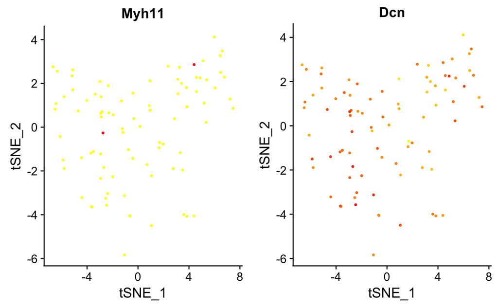

```r
genes_to_check = c('Myh11','Dcn')
FeaturePlot(subtiss, genes_to_check, pt.size = 1)
```

Dotplots let you see the intensity of exppression and the fraction of cells expressing for each of your genes of interest.

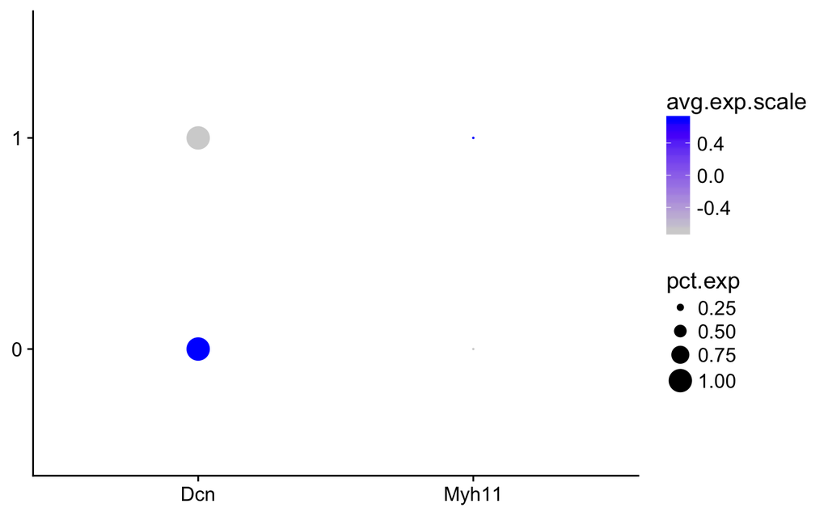

```r
# To change the y-axis to show raw counts, add use.raw = T.
DotPlot(subtiss, genes_to_check, plot.legend = T)
```

How big are the clusters?

```r
table(subtiss@ident)
```

```
 0  1
49 38
```

## Checking for batch effects

Color by metadata, like plate barcode, to check for batch effects.

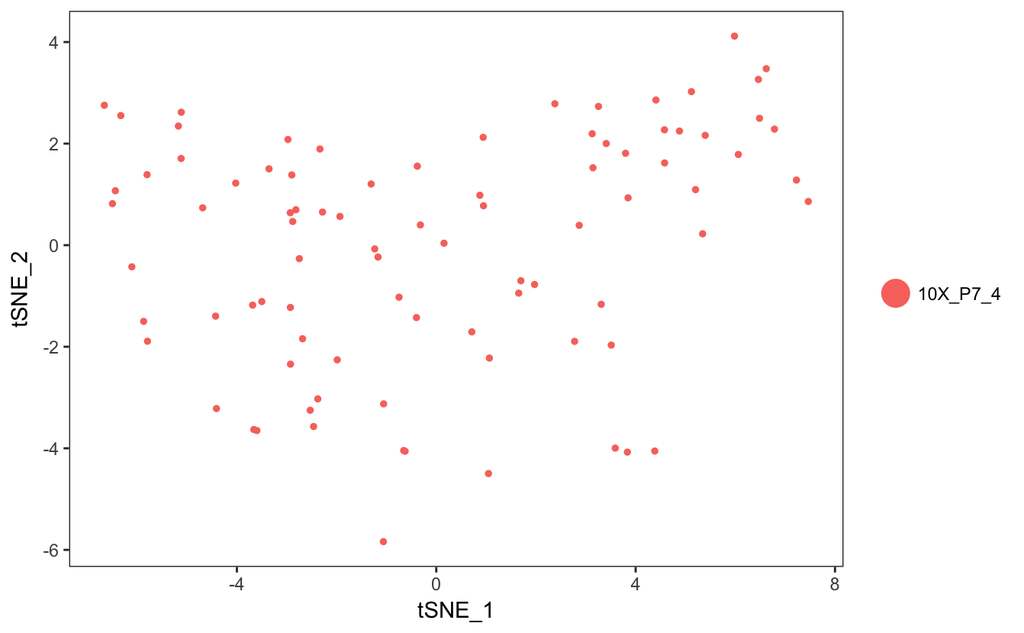

```r
TSNEPlot(object = subtiss, do.return = TRUE, group.by = "channel")
```

Print a table showing the count of cells in each identity category from each plate.

```r
table(as.character(subtiss@ident), as.character(subtiss@meta.data$channel))
```

```
    10X_P7_4
  0       49
  1       38
```

### Assigning subcell_ontology_classs

For the subsets, we produce subcell_ontology_classs. These will be written back as metadata in the original object, so we can see all subcell_ontology_classs together.

If some of the clusters you find in the subset deserve additional cell_ontology_class, you can add that right here. Use NA for clusters for which no subcell_ontology_class is needed.

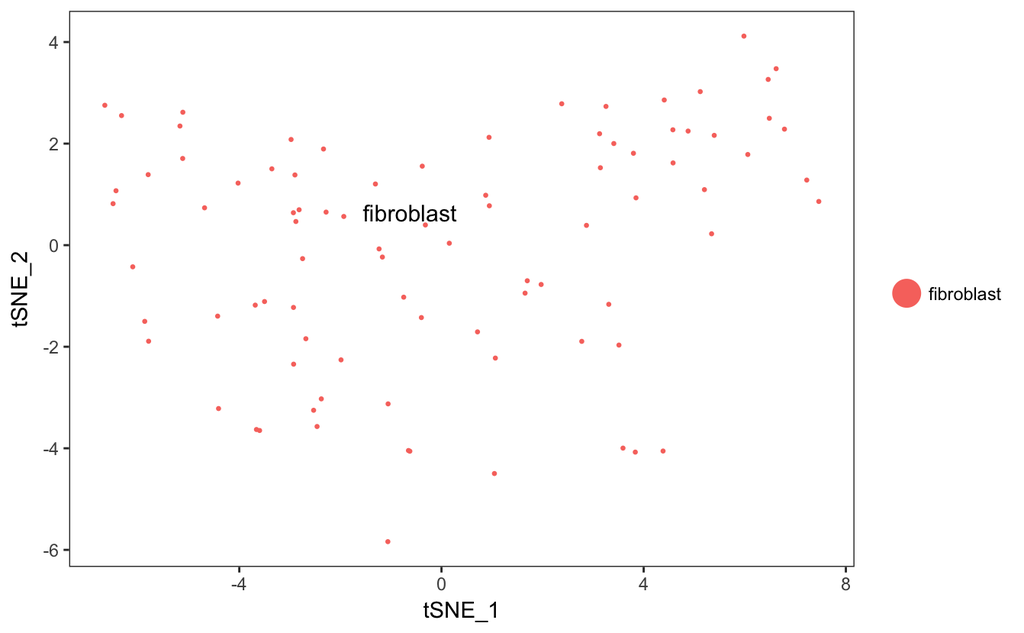

```r
subcluster.ids <- c(0, 1)
subcell_ontology_class <- c("fibroblast", "fibroblast")
subcell_ontology_id = c("CL:0000057", "CL:0000057")
subtiss@meta.data[,'cell_ontology_class'] <- plyr::mapvalues(x = subtiss@ident, from = subcluster.ids, to = subcell_ontology_class)
subtiss@meta.data[,'cell_ontology_id'] <- plyr::mapvalues(x = subtiss@ident, from = subcluster.ids, to = subcell_ontology_id)
tiss@meta.data[subtiss@cell.names,'cell_ontology_class'] <- as.character(subtiss@meta.data$cell_ontology_class)
tiss@meta.data[subtiss@cell.names,'cell_ontology_id'] <- as.character(subtiss@meta.data$cell_ontology_id)
TSNEPlot(object = subtiss, do.label = TRUE, pt.size = 0.5, group.by='cell_ontology_class')
```

Check the numbers of cells per cell_ontology_class

```r
table(tiss@meta.data$cell_ontology_class)
```

```
   endothelial cell          fibroblast         erythrocyte    endocardial cell
                177                 222                  81                  63
cardiac muscle cell  Smooth Muscle Cell
                 60                  21
```

# Save the Robject for later

When you save the annotated tissue, please give it a name.

```r
filename = here('00_data_ingest', '04_tissue_robj_generated',
          paste0("droplet", tissue_of_interest, "_seurat_tiss.Robj"))
print(filename)
```

```
[1] "/Users/guangli/Documents/GitHub/tabula-muris/00_data_ingest/04_tissue_robj_generated/dropletHeart_seurat_tiss.Robj"
```

```r
save(tiss, file=filename)
```

```r
# To reload a saved object
# filename = here('00_data_ingest', '04_tissue_robj_generated',
#                      paste0("facs", tissue_of_interest, "_seurat_tiss.Robj"))
# load(file=filename)
```

# Export the final metadata

So that Biohub can easily combine all your cell_ontology_classs, please export them as a simple csv.

```r
head(tiss@meta.data)
```

|  | nGene | nUMI | orig.ident | channel | tissue | subtissue | mouse.sex | percent.ercc | percent.ribo | free_annotation | cell_ontology_class | res.0.5 | cluster.ids | cell_ontology_id |
| --- | --- | --- | --- | --- | --- | --- | --- | --- | --- | --- | --- | --- | --- | --- |
| 10X_P7_4_AAACCTGCACGACGAA | 2063 | 4680 | 10X | 10X_P7_4 | Heart | NA | F | 0 | 0.1611111 | NA | endothelial cell | 0 | 0 | CL:0000115 |
| 10X_P7_4_AAACCTGGTTCCACGG | 2040 | 4330 | 10X | 10X_P7_4 | Heart | NA | F | 0 | 0.1623557 | NA | fibroblast | 1 | 1 | CL:0000057 |
| 10X_P7_4_AAACCTGTCTCGATGA | 2024 | 3851 | 10X | 10X_P7_4 | Heart | NA | F | 0 | 0.1007531 | NA | endothelial cell | 0 | 0 | CL:0000115 |
| 10X_P7_4_AAACGGGAGCGCTCCA | 1449 | 3902 | 10X | 10X_P7_4 | Heart | NA | F | 0 | 0.2916453 | NA | erythrocyte | 3 | 3 | CL:0002350 |
| 10X_P7_4_AAAGCAAAGTGAATTG | 832 | 1676 | 10X | 10X_P7_4 | Heart | NA | F | 0 | 0.1533413 | NA | fibroblast | 1 | 1 | CL:0000057 |
| 10X_P7_4_AAAGCAACACCGAAAG | 930 | 2081 | 10X | 10X_P7_4 | Heart | NA | F | 0 | 0.2820759 | NA | endocardial cell | 4 | 4 | CL:0000746 |

```r
filename = here('00_data_ingest', '03_tissue_cell_ontology_class_csv',
          paste0(tissue_of_interest, "_droplet_cell_ontology_class.csv"))
write.csv(tiss@meta.data[,c('channel','cell_ontology_class','cell_ontology_id')], file=filename)
```

[output not shown]